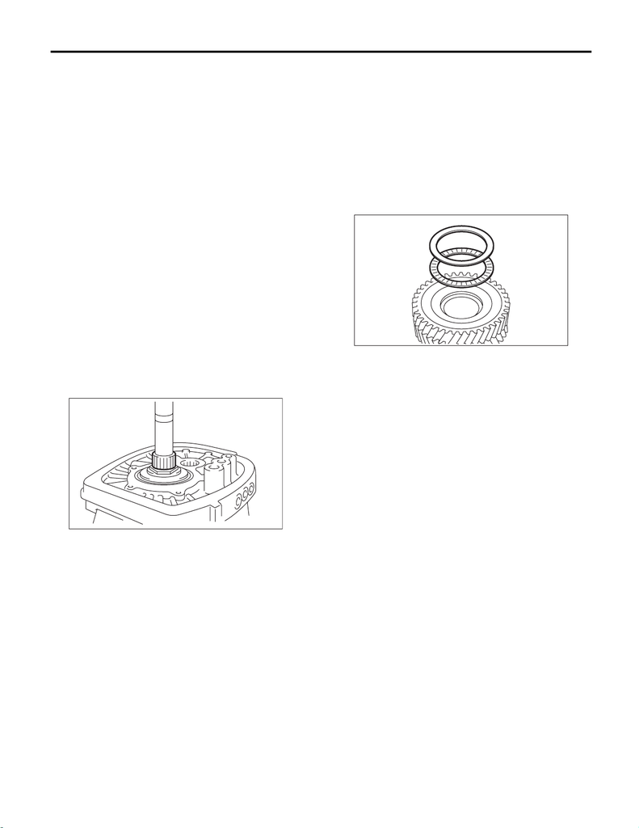

6MT(TY85)-77

Driven Gear Assembly

MANUAL TRANSMISSION AND DIFFERENTIAL

20.Driven Gear Assembly

A: REMOVAL

1) Remove the manual transmission assembly

from the vehicle. <Ref. to 6MT(TY85)-31, REMOV-

AL, Manual Transmission Assembly.>

2) Prepare the transmission for overhaul. <Ref. to

6MT(TY85)-38, Preparation for Overhaul.>

3) Remove the neutral position switch, back-up

light switch and harness. <Ref. to 6MT(TY85)-41,

REMOVAL, Neutral Position Switch.> <Ref. to

6MT(TY85)-40, REMOVAL, Back-up Light

Switch.>

4) Remove the extension case. <Ref. to

6MT(TY85)-42, REMOVAL, Extension Case.>

5) Remove the transfer driven gear. <Ref. to

6MT(TY85)-54, REMOVAL, Transfer Driven

Gear.>

6) Remove the center differential. <Ref. to

6MT(TY85)-56, REMOVAL, Center Differential.>

7) Remove the transmission case. <Ref. to

6MT(TY85)-57, REMOVAL, Transmission Case.>

8) Remove the driven gear assembly. <Ref. to

6MT(TY85)-63, REMOVAL, Main Shaft Assem-

bly.>

9) Remove the 1st needle bearing.

10) Remove the thrust needle bearing.

B: INSTALLATION

1) Adjust the main shaft snap ring. <Ref. to

6MT(TY85)-75, ADJUSTMENT, Main Shaft As-

sembly.>

2) Adjust the 1st-2nd shifter rod. <Ref. to

6MT(TY85)-110, ADJUSTMENT, Shifter Fork and

Rod.>

3) Install the thrust needle bearing.

NOTE:

Confirm that the thrust needle bearing is installed in

the proper direction.

4) Install the needle bearing.

5) Install the driven gear assembly. <Ref. to

6MT(TY85)-64, INSTALLATION, Main Shaft As-

sembly.>

6) Install the transmission case. <Ref. to

6MT(TY85)-59, INSTALLATION, Transmission

Case.>

7) Adjust the backlash of the driven gear assembly

in the axial direction. <Ref. to 6MT(TY85)-86, AD-

JUSTMENT, Driven Gear Assembly.>

8) Install the center differential. <Ref. to

6MT(TY85)-56, INSTALLATION, Center Differen-

tial.>

9) Install the transfer driven gear. <Ref. to

6MT(TY85)-54, INSTALLATION, Transfer Driven

Gear.>

10) Install the extension case. <Ref. to 6MT(TY85)-

42, INSTALLATION, Extension Case.>

11) Install the neutral position switch, back-up light

switch and harness. <Ref. to 6MT(TY85)-41, IN-

STALLATION, Neutral Position Switch.> <Ref. to

6MT(TY85)-40, INSTALLATION, Back-up Light

Switch.>

12) Install the manual transmission assembly to the

vehicle. <Ref. to 6MT(TY85)-33, INSTALLATION,

Manual Transmission Assembly.>

MT-00586

MT-00587

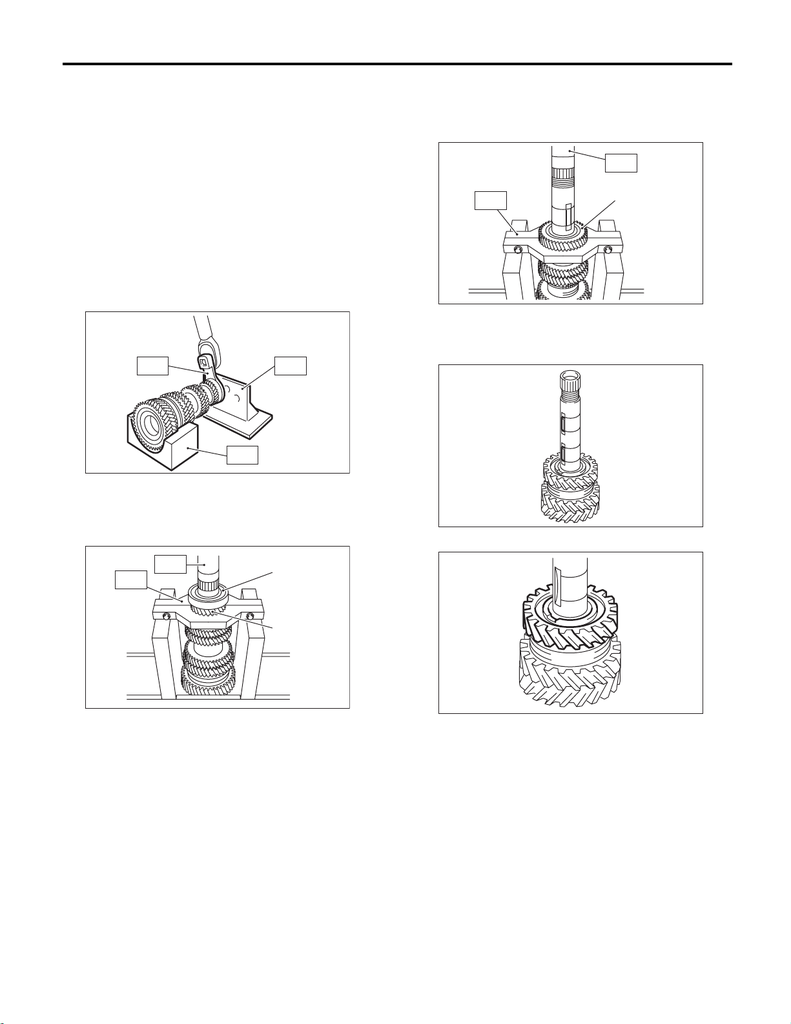

6MT(TY85)-78

Driven Gear Assembly

MANUAL TRANSMISSION AND DIFFERENTIAL

C: DISASSEMBLY

NOTE:

Individual coupling sleeves and synchronizer hubs

meet at a specified position. Before disassembly,

mark the meeting position of the coupling sleeve

and synchronizer hub.

1) Affix the ST to the work table.

ST 18664AA000 BASE

2) Flatten the tab of the lock nut.

3) Attach ST3 to the lock nut, set the driven gear

assembly to the ST, and remove the lock nut.

ST1 18666AA000 HOLDER

ST2 18664AA000 BASE

ST3 18620AA000 ADAPTER WRENCH

4) Attach ST1 to the 6th driven gear, then remove

the ball bearing and 5th-6th driven gear.

ST1 18723AA000 REMOVER

ST2 499877000 RACE 4-5 INSTALLER

5) Attach ST1 to the 4th driven gear, then remove

the 3rd-4th driven gear.

ST1 18723AA000 REMOVER

ST2 499877000 RACE 4-5 INSTALLER

6) Remove the key.

7) Remove the 2nd driven gear.

(A) Ball bearing

(B) 5th-6th driven gear

MT-00588

ST3

ST2

ST1

MT-01480

(A)

(B)

ST2

ST1

(A) 3rd-4th driven gear

MT-01481

(A)

ST2

ST1

MT-00590

MT-00591

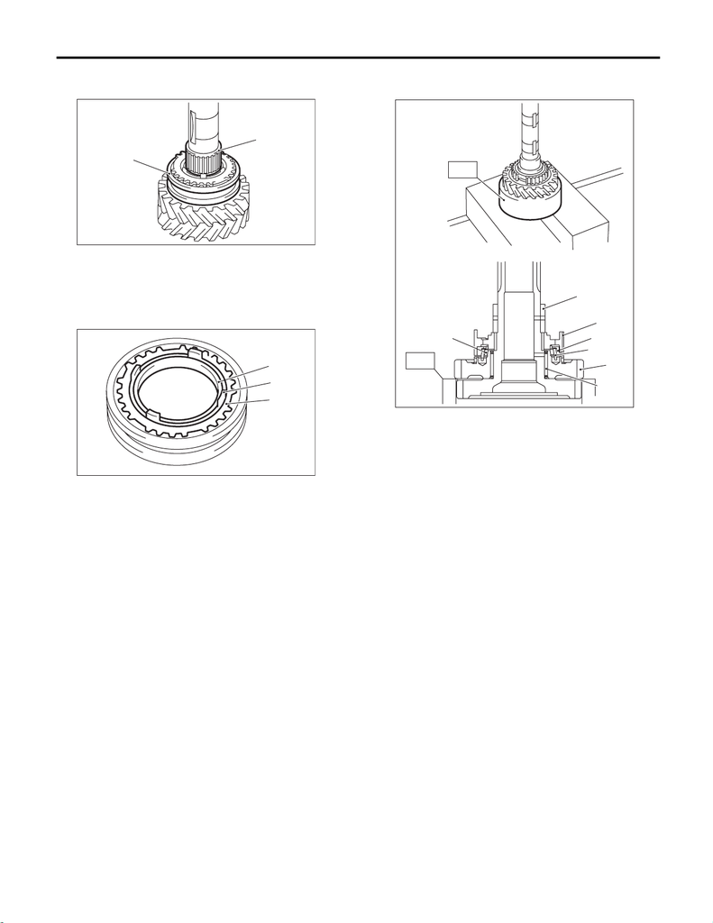

6MT(TY85)-79

Driven Gear Assembly

MANUAL TRANSMISSION AND DIFFERENTIAL

8) Remove the needle bearing and 1st-2nd cou-

pling sleeve.

9) Remove the 2nd outer baulk ring, 2nd synchro

cone and 2nd inner baulk ring.

10) Using the ST, remove individual parts.

ST 18754AA000 REMOVER

(A) Needle bearing

(B) 1st-2nd coupling sleeve

(A) 2nd outer baulk ring

(B) 2nd synchro cone

(C) 2nd inner baulk ring

MT-00592

(A)

(B)

MT-01502

(B)

(A)

(C)

(A) 2nd drive gear bushing

(B) 1st-2nd synchronizer hub

(C) 1st outer baulk ring

(D) 1st synchro cone

(E) 1st inner baulk ring

(F) 1st driven gear

(G) Needle bearing

(A)

(E)

(B)

(C)

(D)

(F)

(G)

MT-01715

ST

ST

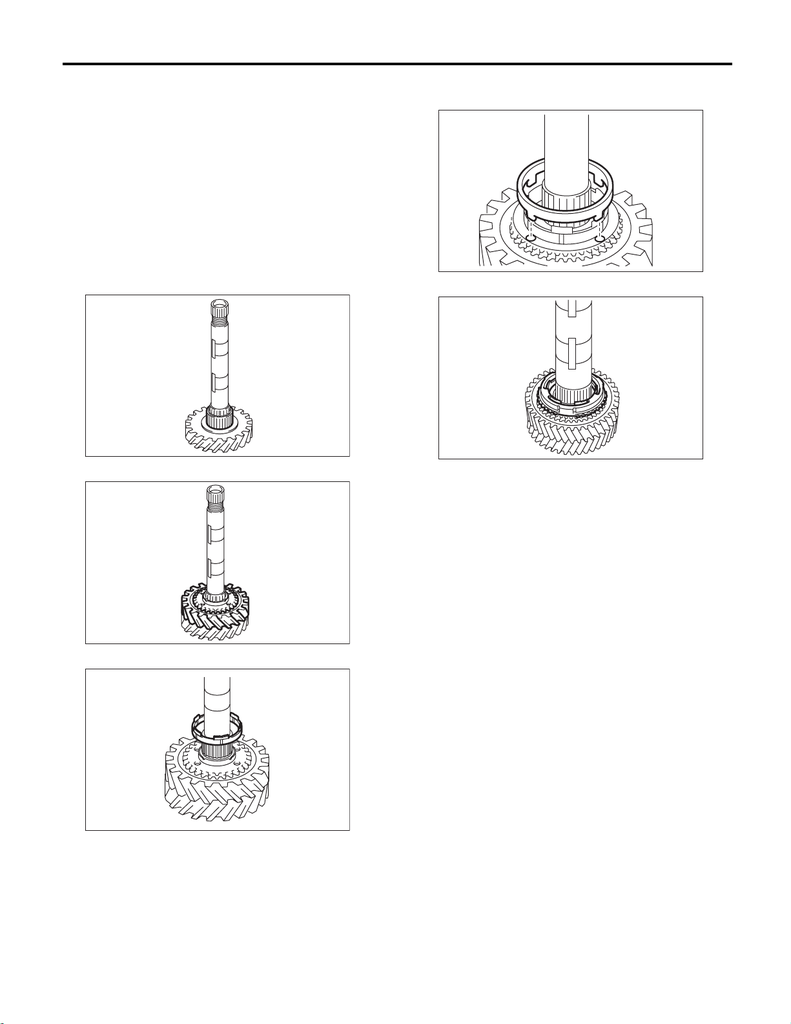

6MT(TY85)-80

Driven Gear Assembly

MANUAL TRANSMISSION AND DIFFERENTIAL

D: ASSEMBLY

NOTE:

When replacing the following parts, replace as a

set.

• Coupling sleeve and synchronizer hub

• 1st outer baulk ring, 1st synchro cone and 1st in-

ner baulk ring

• 2nd outer baulk ring, 2nd synchro cone and 2nd

inner baulk ring.

1) Apply adequate transmission gear oil to the main

shaft, needle bearing and 1st driven gear inner sur-

face.

2) Install the needle bearing.

3) Attach the 1st driven gear to the driven shaft.

4) Install the 1st inner baulk ring.

5) Match the protrusion of the 1st synchro cone to

the hole of the 1st driven gear, then install.

6) Install the 1st outer baulk ring.

MT-00595

MT-01729

MT-01730

MT-01505

MT-00599

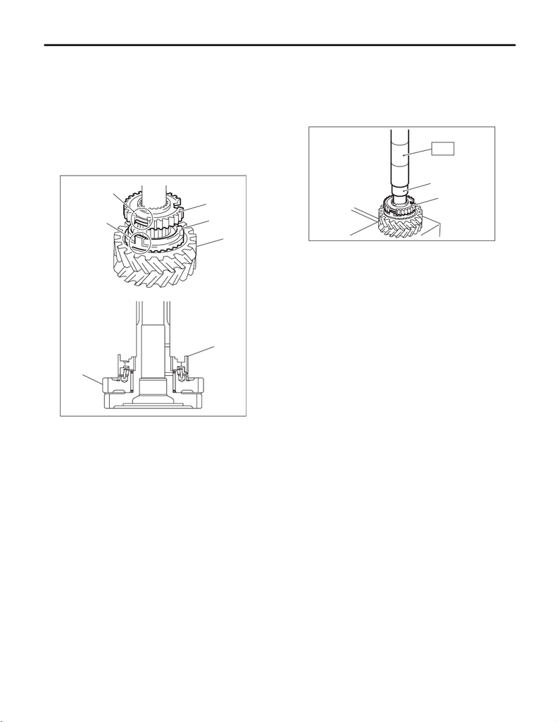

6MT(TY85)-81

Driven Gear Assembly

MANUAL TRANSMISSION AND DIFFERENTIAL

7) Install the 1st-2nd synchronizer hub.

CAUTION:

Apply transmission gear oil onto sliding or re-

volving surfaces before installation.

NOTE:

• Match the cut out of the 1st-2nd synchronizer

hub with the protrusion on the outer baulk ring, then

install.

• Make sure that the 1st-2nd synchronizer hub is

installed in the correct direction.

8) Using the ST, install the 1st-2nd synchronizer

hub and 2nd driven gear bushing.

ST 18654AA000 INSTALLER

CAUTION:

Do not apply pressure in excess of 40 kN (4.0

ton, 4.4 US ton, 3.9 Imp ton).

9) Make sure that the 1st driven gear can be turned

smoothly by hand. If it does not turn smoothly, re-

assemble.

(A) 1st-2nd synchronizer hub

(B) 1st outer baulk ring

(C) Cut out of the 1st-2nd synchronizer hub

(D) Protrusion of the 1st outer baulk ring

(E) 1st driven gear

MT-01716

(E)

(D)

(C)

(A)

(B)

(E)

(A)

(A) 2nd driven gear bushing

(B) 1st-2nd synchronizer hub

MT-00601

(B)

(A)

ST

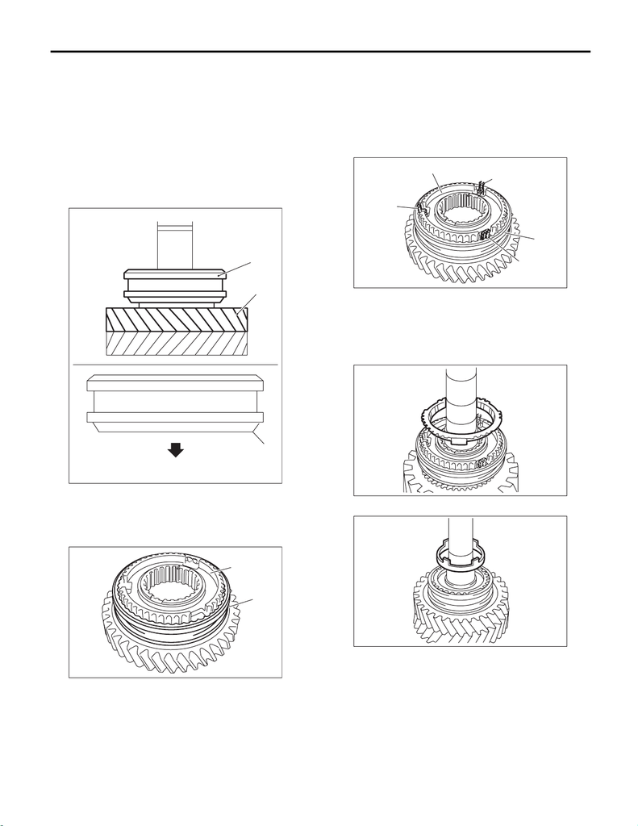

6MT(TY85)-82

Driven Gear Assembly

MANUAL TRANSMISSION AND DIFFERENTIAL

10) Attach the 1st-2nd coupling sleeve to the 1st-

2nd synchronizer hub.

NOTE:

• Make sure that the 1st-2nd coupling sleeve is in-

stalled in the correct direction.

• Align the 1st-2nd synchronizer hub cut out sec-

tion (three places) and the key grooves (three plac-

es) of shifting insert that are located inside the 1st-

2nd coupling sleeve.

• Set the 1st-2nd coupling sleeve and 1st driven

gear so that they contact each other.

11) Attach the shifting insert to the appropriate po-

sition of the 1st-2nd coupling sleeve.

NOTE:

• The location angle of each shifting insert is 120°.

• Install the shifting insert to the key grooves (three

places) of shifting insert that are located inside the

1st-2nd coupling sleeve.

12) Install the 2nd outer baulk ring.

13) Install the 2nd synchro cone.

(A) 1st driven gear

(B) 1st-2nd coupling sleeve

(C) 1st driven gear side

(A) 1st-2nd synchronizer hub

(B) 1st-2nd coupling sleeve

MT-00603

(B)

(A)

(C)

(B)

MT-01731

(A)

(B)

(A) Shifting insert

(B) 1st-2nd synchronizer hub

(C) 1st-2nd coupling sleeve

MT-01732

(A)

(B)

(C)

(A)

(A)

MT-01733

MT-01506

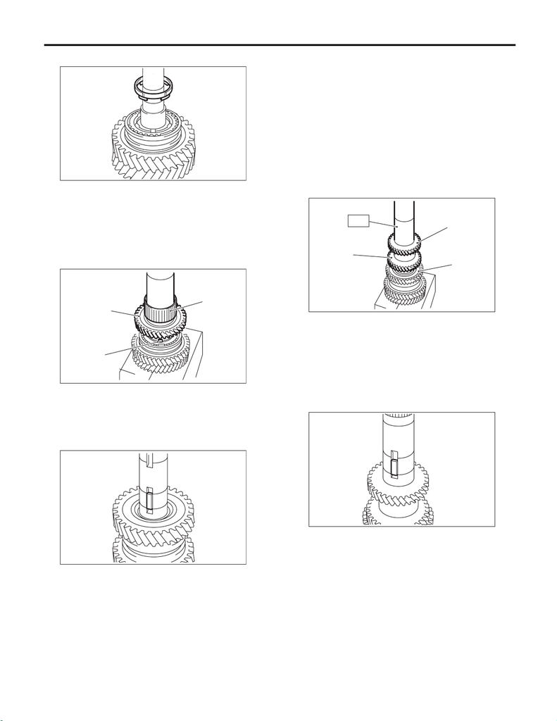

6MT(TY85)-83

Driven Gear Assembly

MANUAL TRANSMISSION AND DIFFERENTIAL

14) Install the 2nd inner baulk ring.

15) Apply adequate transmission gear oil to the

2nd driven gear bushing, needle bearing and 2nd

driven gear inner surface.

16) Install the needle bearing and 2nd driven gear.

NOTE:

Match the protrusion of the 2nd synchro cone to the

hole of the 2nd driven gear, then install.

17) Attach the key.

18) Using the ST, install the 3rd-4th driven gear.

ST 18654AA000 INSTALLER

CAUTION:

• Do not apply pressure in excess of 40 kN (4.0

ton, 4.4 US ton, 3.9 Imp ton).

• Apply transmission gear oil onto sliding or

revolving surfaces before installation.

NOTE:

• Make sure that the 3rd-4th driven gear is in-

stalled in the correct direction.

• Match the groove on the 3rd-4th driven gear to

the key.

19) Make sure that the 2nd driven gear can be

turned smoothly by hand. If it does not turn smooth-

ly, reassemble.

20) Attach the key.

(A) Needle bearing

(B) 2nd driven gear

(C) Protrusion of the 2nd synchro cone

MT-00606

MT-00607

(A)

(C)

(B)

MT-00608

(A) 4th gear

(B) 3rd gear

(C) 2nd gear

MT-00609

(A)

(C)

(B)

ST

MT-00610

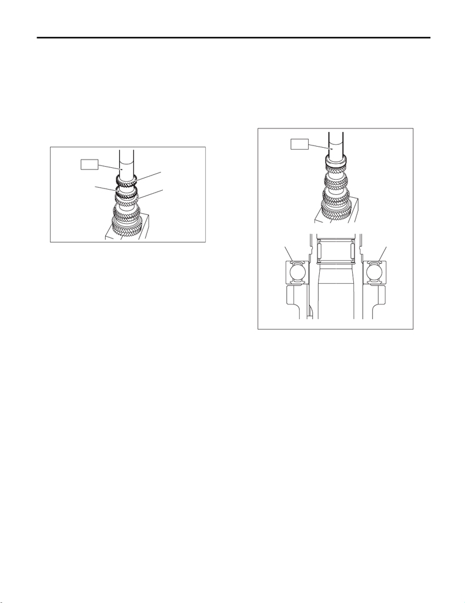

6MT(TY85)-84

Driven Gear Assembly

MANUAL TRANSMISSION AND DIFFERENTIAL

21) Using the ST, install the 5th-6th driven gear.

ST 18654AA000 INSTALLER

CAUTION:

Do not apply pressure in excess of 40 kN (4.0

ton, 4.4 US ton, 3.9 Imp ton).

NOTE:

• Make sure that the 5th-6th driven gear is in-

stalled in the correct direction.

• Match the groove on the 5th-6th driven gear to

the key.

22) Using the ST, install the ball bearing.

ST 18654AA000 INSTALLER

CAUTION:

Do not apply pressure in excess of 40 kN (4.0

ton, 4.4 US ton, 3.9 Imp ton).

NOTE:

Face the sealing section of the ball bearing to the

lock nut side, and install the ball bearing.

23) Make sure that the ball bearing turns smoothly

by hand. If it does not turn smoothly, reassemble.

24) Install a new lock nut.

(A) 6th gear

(B) 5th gear

(C) 4th gear

MT-00611

(B)

ST

(A)

(C)

(A) Sealing

MT-02108

ST

(A)

(A)

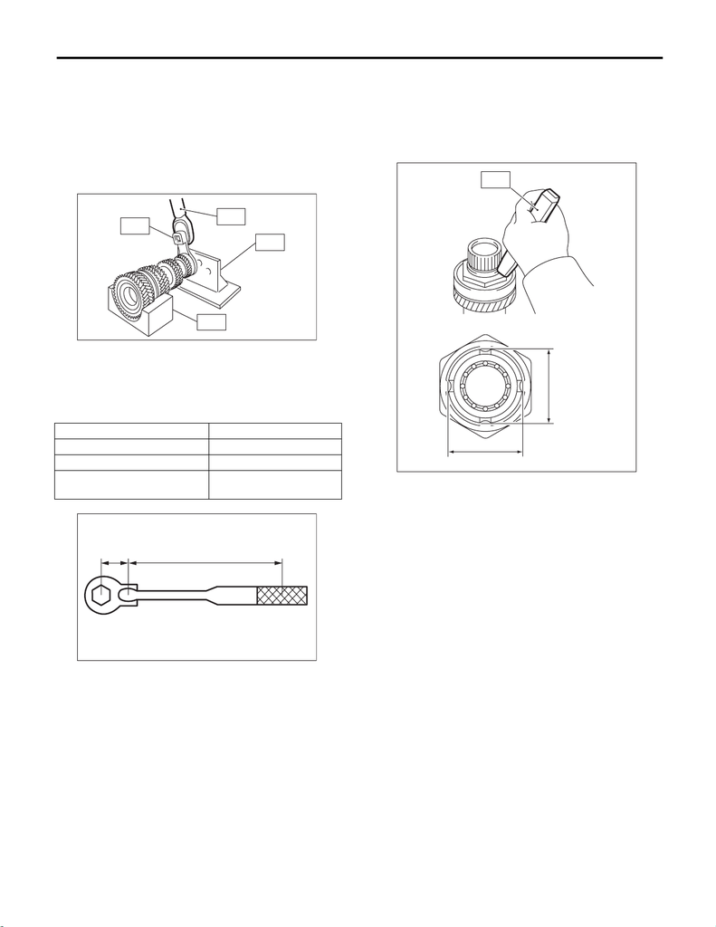

6MT(TY85)-85

Driven Gear Assembly

MANUAL TRANSMISSION AND DIFFERENTIAL

25) Attach ST3 to the lock nut, attach ST to the driv-

en gear assembly, and tighten the lock nut.

ST1 18666AA000 HOLDER

ST2 18664AA000 BASE

ST3 18620AA000 ADAPTER WRENCH

ST4 18852AA000 TORQUE WRENCH

Tightening torque:

NOTE:

When using a torque wrench other than ST4, use

the calculation below to calculate and tighten the

lock nut.

T = L1/(0.1 + L1) × 570

26) Using the ST, crimp the lock nut in 4 locations,

with dimensions within A 44±0.5 mm (1.73±0.02

in).

ST 18669AA000 PUNCH DRIVEN SHAFT

NOTE:

Do not damage the crimp area of the lock nut.

T N·m (kgf-m, ft-lb) Torque wrench setting

L1 m (in) Torque wrench length

0.1 m (3.94 in) Length of ST

570 N·m (58.1 kgf-m, 420 ft-lb) Tightening torque (lock

nut)

(A) 0.1 m (3.94 in)

MT-00613

ST1

ST2

ST4

ST3

MT-00614

(A)

L1

MT-00615

A

A

ST

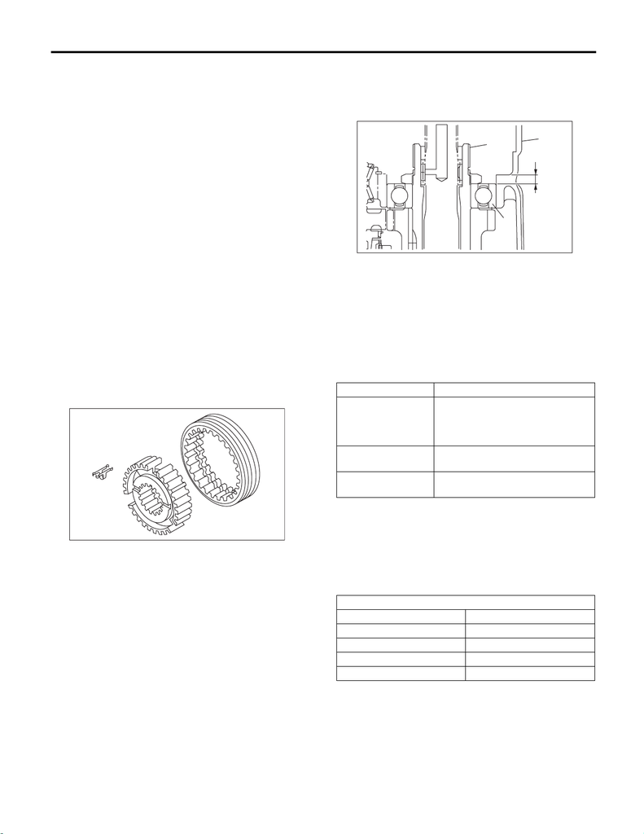

6MT(TY85)-86

Driven Gear Assembly

MANUAL TRANSMISSION AND DIFFERENTIAL

E: INSPECTION

Disassembled parts should be washed with clean-

ing solvent first, then inspected carefully.

1) Bearing

Replace the bearings in the following cases.

• Wear, rusting or damage of the bearings

• The bearing does not rotate smoothly or an ab-

normal noise is emitted when turning.

• The bearing has other defects.

2) Bushing (each gear)

Replace the bushing in following cases.

• The sliding surface is damaged or abnormally

worn.

3) Gear

Replace gears in the following cases.

• The gear teeth surface is damaged or excessive-

ly worn.

• The contact area of the baulk ring is damaged.

• The inner face of the gear is worn.

4) Baulk ring, synchro cone

Replace the baulk ring and synchro cone in the fol-

lowing cases.

• Wear, rusting or damage of the baulk ring

5) Shifting insert

Replace the shifting insert key if deformed, exces-

sively worn or defective in any way.

F: ADJUSTMENT

1) Measure the length “H” from the transmission

case and transfer bearing holder mating surface, to

the end face of the ball bearing.

2) Using the following calculation, calculate the

thickness of the driven gear assembly adjusting

washer.

T = H – {5.8±0.05 mm (0.23±0.002 in)} – {0.1 — 0.3

mm (0.0039 — 0.0118 in)}

3) Select 0 to 3 adjusting washers from the follow-

ing table, and adjust to the backlash that is closest

to the standard value.

Driven gear assembly axial direction backlash

standard:

0.1 — 0.3 mm (0.0039 — 0.0118 in)

MT-00581

(A) Transmission case

(B) Ball bearing

(C) Driven gear ASSY

T Adjusting washer thickness

H Length from the transmission case

and transfer bearing holder mating

surface to the end face of the ball

bearing

5.8±0.05 mm

(0.23±0.002 in)

Collar thickness

0.1 — 0.3 mm

(0.0039 — 0.0118 in)

Driven gear assembly axial direc-

tion backlash standard

Adjusting washer

Part No. Thickness T mm (in)

803072030 0.15 (0.0059)

803072031 0.30 (0.0118)

803072032 0.45 (0.0177)

803072033 0.60 (0.0236)

MT-00616

(A)

H

(C)

(B)